# Grupo II - Avaliação de indicadores de práticas de saúde em relação a variáveis socioeconômicas

# 1 Introdução

A adoção de estratégias de práticas de saúde no ambiente escolar ou em comunidades mais amplas oferece inúmeros benefícios à população atendida. Nesse contexto, diante de um cenário marcado por desigualdades sociais e heterogeneidade nos indicadores socioeconômicos, a avaliação da relação entre esses indicadores e o contexto socioeconômico regional torna-se essencial. Tal análise é fundamental para promover maior eficiência no planejamento e na implementação de políticas públicas, além de possibilitar comparações entre diferentes regiões e o país de forma abrangente.

Desta forma, a presente pesquisa possui o objetivo de avaliar a relação dos indicadores socioeconomicos com os indicadores de pratica de saúde no ano de 2023 no Brasil.

# 2 Objetivo

O presente estudo possui o objetivo de verificar a relação entre os indicadores socioeconômicos com indicadores sínteses de promoção à saúde .

# 3 Referencial Teórico

# 3.1 Estudos de práticas de promoção à saúde

A OMS (Organização mundial da saúde) por meio da carta de Ottawa define a promoção à saúde como processo de capacitação da comunidade para atuar na melhoria de sua qualidade de vida e saúde, incluindo uma maior participação no controle deste processo. Esta definição apresenta um caráter mais amplo pois impacta os elementos que afetam a qualidade de vida das pessoas, englobando assim aspectos econômicos, sociais educacionais, lazer etc.

A promoção à saúde é um tema de alta relevância nas políticas públicas sanitárias. A mudança de paradigma nos conceitos de definição de saúde e na sua abordagem trouxeram novas perspectivas no desenvolvimento de soluções sanitárias para a sociedade. Desta forma, Heidman et. al (2006) destaca o caráter intersetorial e a elaboração de políticas públicas como pilares da promoção à saúde. Além disso dentro do contexto latino-americano, a promoção à saúde se torna mais relevante por oferecer ferramentas que proporcionam maior equidade no acesso as soluções sanitárias.

Neste contexto, como práticas a promoção a saúde temos os seguintes grupos de indicadores:

- Indicadores de temas de saúde;
- Indicadores de práticas de saúde;
- Indicadores de práticas de promoção a saude nas escolas

Como pontos positivos para as praticas de promoção a saúde nas escolas, Baggio et al (2019) destacam que o programa pode proporcionar interação entre saúde, escola e família e consequente vinculação desta última à Unidade Básica de Saúde, permeada pela interação colaborativa entre profissionais de saúde e educação. Problemas na implantação do PSE são capazes de fornecer subsídios para a compreensão de cenários, como restrita articulação na gestão dos entes federal e municipal, bem como a fragilidade na articulação entre os setores de educação e saúde.

Assim, o impacto das políticas públicas afeta de maneira relevante a saúde de uma comunidade. Neste contexto, Buss et.al (2020) destacam que os profissionais de saúde, os movimentos sociais e as organizações populares, políticos e autoridades públicas têm responsabilidades sobre as repercussões positivas ou negativas que as políticas públicas têm sobre a situação de saúde e as condições de vida. A estratégia dos municípios saudáveis é uma das iniciativas que pode proporcionar a promoção da saúde através da ação intersetorial.

Nesta linha, o Ministério da Saúde (2010), afirma a promoção da saúde é uma estratégia de interligada transversalmente na qual se verifica visibilidade aos fatores que colocam a saúde da população em risco e às diferenças entre necessidades, territórios e culturas presentes no nosso país, visando à criação de instrumentos e procedimentos que reduzam as situações de vulnerabilidade, defendam radicalmente a equidade e incorporem a participação e o controle sociais na gestão das políticas públicas. De forma complementar, Buss (2000) destaca que a relações intersetorial e entre população e o Estado, assim como a qualificação para o exercício da cidadania e do controle social são contribuições relevantes que o exercício da promoção da saúde, por profissionais e ativistas da saúde, pode trazer para a sociedade.

Em relação aos benefícios trazidos pela promoção à saúde para a comunidade, Pinheiro et. al (2023) destaca a relevância da educação em saúde como instrumento para prevenção e promoção da saúde da sociedade. As atividades educacionais, apresentaram um grande potencial de influência na adesão de comportamentos saudáveis de vida com o objetivo de prevenir de doenças e promover o bem-estar, uma vez que as estratégias utilizadas, como as orientações verbais, uso de cartazes e distribuição de panfletos possibilitaram a ampliação de conhecimento e aproximação dos estudantes com a população.

# 4 Metodologia

O presente estudo possui uma abordagem de pesquisa quantitativa e, em relação a seu objetivo, esta pesquisa possui um perfil exploratório, uma vez que apresentará o resultado da análise quantitativa da relação dos indicadores socioeconômicos com os indicadores síntese de práticas de saúde.

Os dados socioeconômicos tiveram como período de referência o ano de 2023 e foram coletados por meio do pacote `ipeadataR` e importados para o RStudio. Foram coletadas as seguintes variáveis:

- IDHM (Estados, Municípios, Regional e Federal);
- PIB a preços de mercado (Estados, Municípios, Regional e Federal);
- Índice de Gini (Estados, Municípios, Regional e Federal);
- Índice de Vulnerabilidade Social (Estados, Municípios, Regional e Federal).

No que diz respeito aos indicadores síntese de práticas de saúde, foram coletados a partir dos dados disponibilizados pela Secretaria de Atenção Primária à Saúde (SAPS/MS) em relação ao ano de 2023, conforme descrição abaixo:

**Tabela 1 – Variáveis analisadas**

| Grupo | Variável |
| --- | --- |
| Temas de saúde | Saúde bucal |
| Temas de saúde | Alimentação saudável |
| Temas de saúde | Saúde sexual e reprodutiva |
| Temas de saúde | Saúde mental |
| Temas de saúde | Autocuidado de pessoas com doenças crônicas |
| Práticas de saúde | Antropometria |
| Práticas de saúde | Práticas corporais/atividade física |
| Práticas de saúde | Verificação da saúde vacinal |
| Prog. saúde nas escolas | Educação |
| Prog. saúde nas escolas | Saúde |
| Bolsa Família | Percentual de cobertura de beneficiários acompanhados |

*Fonte: Elaboração própria*

Os indicadores foram construídos com base em proporções relativas a diferentes contextos. No que diz respeito aos indicadores de práticas e temas de saúde, considerou-se a razão entre a quantidade de práticas de saúde e a população cadastrada pelo IBGE.

No que tange aos indicadores do Programa Saúde nas Escolas, adotou-se a razão entre a quantidade de práticas de saúde nas escolas e o quantitativo de estabelecimentos de ensino participantes do programa.

Por fim, sobre a variável de percentual de cobertura de beneficiários acompanhados pelo Bolsa Família, como o dado já está padronizado em percentual, considerou-se que a avaliação em relação aos indicadores socioeconômicos será direta.

# 5 Análise de Resultados

# 5.1 Tabela indicadores de saúde bucal

## Dados por UF

| UF | Regiao | indicador | media | mediana | desvio_padrao | minimo | maximo | pvalor_shapiro | Numerador | Denominador | n_municip |
| --- | --- | --- | --- | --- | --- | --- | --- | --- | --- | --- | --- |
| DISTRITO FEDERAL | CENTRO-OESTE | 0.24 | 0.24 | 0.24 | NA | 0.24 | 0.24 | NA | 5 | 2091149 | 1 |
| GOIAS | CENTRO-OESTE | 124.28 | 309.87 | 93.30 | 850.10 | 0.00 | 11050.97 | 0.00000 | 6584 | 5297680 | 239 |
| MATO GROSSO | CENTRO-OESTE | 340.59 | 520.68 | 232.19 | 769.71 | 0.00 | 4264.32 | 0.00000 | 10498 | 3082321 | 140 |
| MATO GROSSO DO SUL | CENTRO-OESTE | 329.41 | 522.77 | 298.99 | 720.51 | 0.00 | 3864.19 | 0.00000 | 8165 | 2478654 | 79 |
| ALAGOAS | NORDESTE | 560.74 | 850.81 | 504.99 | 1029.45 | 0.62 | 5702.79 | 0.00000 | 14314 | 2552709 | 102 |
| BAHIA | NORDESTE | 194.23 | 276.70 | 158.44 | 374.75 | 0.00 | 3608.12 | 0.00000 | 23616 | 12158963 | 415 |
| CEARA | NORDESTE | 169.02 | 311.49 | 177.07 | 422.82 | 0.00 | 3265.21 | 0.00000 | 14808 | 8761012 | 184 |
| MARANHAO | NORDESTE | 219.68 | 232.64 | 110.33 | 422.32 | 0.00 | 3990.53 | 0.00000 | 13229 | 6022076 | 216 |
| PARAIBA | NORDESTE | 208.03 | 289.92 | 171.72 | 422.95 | 0.00 | 3315.44 | 0.00000 | 7854 | 3775421 | 219 |
| PERNAMBUCO | NORDESTE | 269.48 | 468.11 | 225.26 | 964.92 | 0.24 | 10428.31 | 0.00000 | 20304 | 7534514 | 185 |
| PIAUI | NORDESTE | 189.37 | 233.86 | 152.98 | 261.99 | 0.00 | 1715.38 | 0.00000 | 6032 | 3185217 | 215 |
| RIO GRANDE DO NORTE | NORDESTE | 224.43 | 277.53 | 179.49 | 297.90 | 0.00 | 2069.54 | 0.00000 | 6465 | 2880619 | 167 |
| SERGIPE | NORDESTE | 117.39 | 184.66 | 143.80 | 161.48 | 0.00 | 739.81 | 0.00000 | 2578 | 2196034 | 75 |
| ACRE | NORTE | 310.55 | 314.14 | 203.83 | 277.57 | 11.92 | 1038.45 | 0.00645 | 2143 | 690071 | 21 |
| AMAPA | NORTE | 221.32 | 366.46 | 242.05 | 326.71 | 0.00 | 1098.01 | 0.01320 | 1053 | 475774 | 16 |
| AMAZONAS | NORTE | 209.08 | 698.12 | 385.65 | 1188.60 | 0.00 | 6540.92 | 0.00000 | 6633 | 3172538 | 62 |
| PARA | NORTE | 237.57 | 285.32 | 182.16 | 359.75 | 0.00 | 2414.14 | 0.00000 | 13632 | 5738072 | 141 |
| RONDONIA | NORTE | 93.63 | 178.36 | 98.67 | 286.23 | 0.00 | 1925.58 | 0.00000 | 1326 | 1416214 | 52 |
| RORAIMA | NORTE | 131.13 | 165.32 | 63.16 | 301.20 | 0.00 | 1116.54 | 0.00001 | 716 | 546019 | 15 |
| TOCANTINS | NORTE | 466.56 | 585.41 | 250.60 | 1038.76 | 0.00 | 9454.55 | 0.00000 | 6968 | 1493485 | 136 |
| ESPIRITO SANTO | SUDESTE | 149.13 | 298.99 | 147.67 | 608.21 | 0.00 | 3487.74 | 0.00000 | 3360 | 2253138 | 33 |
| MINAS GERAIS | SUDESTE | 349.65 | 812.53 | 337.84 | 1772.49 | 0.00 | 31217.30 | 0.00000 | 67155 | 19206147 | 851 |
| RIO DE JANEIRO | SUDESTE | 88.30 | 209.38 | 117.87 | 242.96 | 0.00 | 1083.55 | 0.00000 | 10240 | 11596713 | 91 |
| SAO PAULO | SUDESTE | 129.66 | 475.51 | 114.62 | 986.27 | 0.00 | 8291.77 | 0.00000 | 38687 | 29837306 | 607 |
| PARANA | SUL | 460.26 | 1602.68 | 343.06 | 3095.63 | 0.00 | 23759.95 | 0.00000 | 46661 | 10137924 | 382 |
| RIO GRANDE DO SUL | SUL | 218.86 | 511.37 | 197.96 | 925.46 | 0.00 | 8702.29 | 0.00000 | 19532 | 8924305 | 491 |
| SANTA CATARINA | SUL | 240.57 | 725.57 | 174.34 | 1796.69 | 0.00 | 15874.73 | 0.00000 | 16910 | 7029192 | 286 |

Note:  
*A coluna indicador foi calculada pela divisão do total de praticas adotadas (por UF, Regiao ou país) pela coluna de total de população cadastrada no IBGE.

## Dados por Regiao

| Regiao | indicador | media | mediana | desvio_padrao | minimo | maximo | pvalor_shapiro | Numerador | Denominador | n_municip |
| --- | --- | --- | --- | --- | --- | --- | --- | --- | --- | --- |
| CENTRO-OESTE | 195.00 | 410.13 | 157.58 | 809.50 | 0 | 11050.97 | 0 | 25252 | 12949804 | 459 |
| NORDESTE | 222.55 | 320.44 | 172.55 | 539.19 | 0 | 10428.31 | 0 | 109200 | 49066565 | 1778 |
| NORTE | 239.95 | 422.90 | 194.53 | 787.22 | 0 | 9454.55 | 0 | 32471 | 13532173 | 443 |
| SUDESTE | 189.91 | 637.81 | 230.38 | 1453.37 | 0 | 31217.30 | 0 | 119442 | 62893304 | 1582 |
| SUL | 318.51 | 923.92 | 211.43 | 2131.59 | 0 | 23759.95 | 0 | 83103 | 26091421 | 1159 |

Note:  
*A coluna indicador foi calculada pela divisão do total de praticas adotadas (por UF, Regiao ou país) pela coluna de total de população cadastrada no IBGE.

## Dados Nacionais

| Pais | Indicador | Media | Mediana | Desvio_padrao | Min | Max | Pvalor_shapiro | Numerador | Denominador | n_municip |
| --- | --- | --- | --- | --- | --- | --- | --- | --- | --- | --- |
| Brasil | 224.56 | 558.05 | 195.21 | 1356.65 | 0 | 31217.3 | NA | 369468 | 164533267 | 5421 |

Note:  
*A coluna indicador foi calculada pela divisão do total de práticas adotadas (por UF, Regiao ou país) pela população cadastrada segundo o IBGE.

## Gráficos

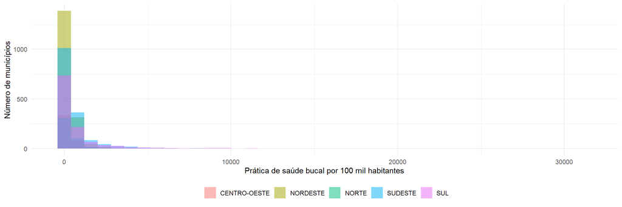

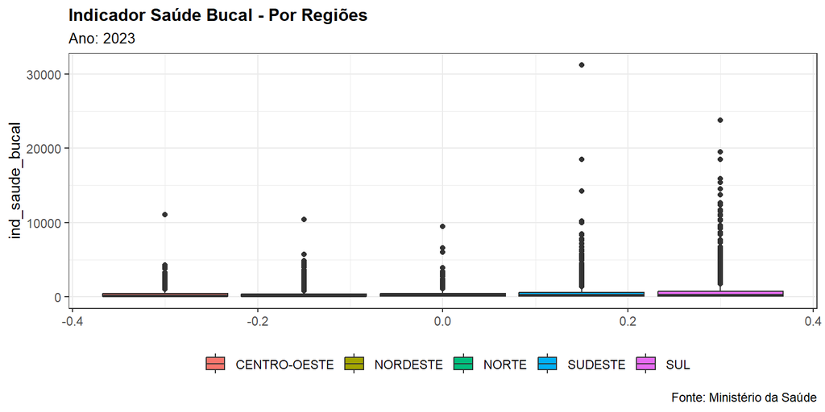

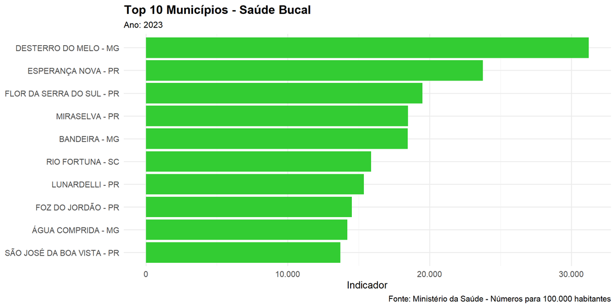

# 5.2 Indicadores de saúde mental

## Dados por UF

| UF | Regiao | Indicador | Media | Mediana | Desvio_pad | Minimo | Maximo | Pvalor_shapiro | Numerador | Denominador | n_municip |
| --- | --- | --- | --- | --- | --- | --- | --- | --- | --- | --- | --- |
| DISTRITO FEDERAL | CENTRO-OESTE | 0.33 | 0.33 | 0.33 | NA | 0.33 | 0.33 | NA | 7 | 2091149 | 1 |
| GOIAS | CENTRO-OESTE | 125.92 | 291.93 | 57.66 | 1142.36 | 0.00 | 15820.15 | 0.00000 | 6671 | 5297680 | 239 |
| MATO GROSSO | CENTRO-OESTE | 142.17 | 168.89 | 41.76 | 411.23 | 0.00 | 3737.70 | 0.00000 | 4382 | 3082321 | 140 |
| MATO GROSSO DO SUL | CENTRO-OESTE | 81.66 | 107.74 | 49.74 | 169.80 | 0.00 | 1043.71 | 0.00000 | 2024 | 2478654 | 79 |
| ALAGOAS | NORDESTE | 182.83 | 236.21 | 109.97 | 480.73 | 0.00 | 4117.37 | 0.00000 | 4667 | 2552709 | 102 |
| BAHIA | NORDESTE | 99.44 | 149.01 | 41.33 | 554.77 | 0.00 | 9937.89 | 0.00000 | 12091 | 12158963 | 415 |
| CEARA | NORDESTE | 86.53 | 155.41 | 63.43 | 274.30 | 0.00 | 1876.04 | 0.00000 | 7581 | 8761012 | 184 |
| MARANHAO | NORDESTE | 90.72 | 96.76 | 57.33 | 145.68 | 0.00 | 1518.35 | 0.00000 | 5463 | 6022076 | 216 |
| PARAIBA | NORDESTE | 99.43 | 160.28 | 47.85 | 477.32 | 0.00 | 5807.94 | 0.00000 | 3754 | 3775421 | 219 |
| PERNAMBUCO | NORDESTE | 134.82 | 148.07 | 82.52 | 199.33 | 0.00 | 1590.82 | 0.00000 | 10158 | 7534514 | 185 |
| PIAUI | NORDESTE | 119.08 | 132.85 | 47.97 | 273.07 | 0.00 | 3172.76 | 0.00000 | 3793 | 3185217 | 215 |
| RIO GRANDE DO NORTE | NORDESTE | 113.41 | 199.64 | 76.34 | 370.87 | 0.00 | 3720.55 | 0.00000 | 3267 | 2880619 | 167 |
| SERGIPE | NORDESTE | 48.91 | 80.45 | 25.92 | 160.07 | 0.00 | 1161.70 | 0.00000 | 1074 | 2196034 | 75 |
| ACRE | NORTE | 106.22 | 180.60 | 52.29 | 387.86 | 0.00 | 1796.24 | 0.00000 | 733 | 690071 | 21 |
| AMAPA | NORTE | 183.28 | 114.44 | 68.38 | 109.21 | 5.83 | 326.82 | 0.01240 | 872 | 475774 | 16 |
| AMAZONAS | NORTE | 177.68 | 489.90 | 193.31 | 890.71 | 0.00 | 4660.65 | 0.00000 | 5637 | 3172538 | 62 |
| PARA | NORTE | 122.65 | 138.89 | 53.18 | 243.48 | 0.00 | 1910.34 | 0.00000 | 7038 | 5738072 | 141 |
| RONDONIA | NORTE | 144.33 | 100.77 | 30.89 | 178.06 | 0.00 | 769.69 | 0.00000 | 2044 | 1416214 | 52 |
| RORAIMA | NORTE | 74.91 | 80.70 | 70.34 | 87.05 | 0.00 | 283.15 | 0.01162 | 409 | 546019 | 15 |
| TOCANTINS | NORTE | 137.46 | 179.14 | 72.82 | 364.70 | 0.00 | 3045.18 | 0.00000 | 2053 | 1493485 | 136 |
| ESPIRITO SANTO | SUDESTE | 56.99 | 56.17 | 23.44 | 77.34 | 0.00 | 310.90 | 0.00000 | 1284 | 2253138 | 33 |
| MINAS GERAIS | SUDESTE | 242.09 | 470.46 | 172.36 | 998.55 | 0.00 | 13825.28 | 0.00000 | 46497 | 19206147 | 851 |
| RIO DE JANEIRO | SUDESTE | 63.47 | 116.92 | 56.69 | 176.03 | 0.00 | 1002.90 | 0.00000 | 7361 | 11596713 | 91 |
| SAO PAULO | SUDESTE | 68.59 | 201.97 | 23.43 | 653.00 | 0.00 | 7072.37 | 0.00000 | 20464 | 29837306 | 607 |
| PARANA | SUL | 96.82 | 203.01 | 24.71 | 1495.35 | 0.00 | 28637.41 | 0.00000 | 9816 | 10137924 | 382 |
| RIO GRANDE DO SUL | SUL | 357.56 | 950.69 | 395.85 | 1869.01 | 0.00 | 24147.89 | 0.00000 | 31910 | 8924305 | 491 |
| SANTA CATARINA | SUL | 107.75 | 221.82 | 49.23 | 531.61 | 0.00 | 6021.99 | 0.00000 | 7574 | 7029192 | 286 |

Note:  
*A coluna indicador foi calculada pela divisão do total de praticas adotadas (por UF, Regiao ou país) pela coluna de total de população cadastrada no IBGE.

## Dados por Regiao

| Regiao | Indicador | Media | Mediana | Desvio_pad | Min | Max | Pvalor_shapiro | Numerador | Denominador | n_municip |
| --- | --- | --- | --- | --- | --- | --- | --- | --- | --- | --- |
| CENTRO-OESTE | 101.04 | 222.06 | 51.59 | 860.32 | 0 | 15820.15 | 0 | 13084 | 12949804 | 459 |
| NORDESTE | 105.67 | 149.53 | 54.05 | 389.07 | 0 | 9937.89 | 0 | 51848 | 49066565 | 1778 |
| NORTE | 138.82 | 195.02 | 67.70 | 441.61 | 0 | 4660.65 | 0 | 18786 | 13532173 | 443 |
| SUDESTE | 120.21 | 338.47 | 84.41 | 849.95 | 0 | 13825.28 | 0 | 75606 | 62893304 | 1582 |
| SUL | 188.95 | 524.40 | 117.69 | 1554.71 | 0 | 28637.41 | 0 | 49300 | 26091421 | 1159 |

Note:  
*A coluna indicador foi calculada pela divisão do total de práticas adotadas (por UF, Regiao ou país) pela coluna de população cadastrada segundo o IBGE.

## Dados Nacionais

[output not shown]

Note:  
*A coluna indicador foi calculada pela divisão do total de práticas adotadas (por UF, Regiao ou país) pela população cadastrada segundo o IBGE.

## Gráficos

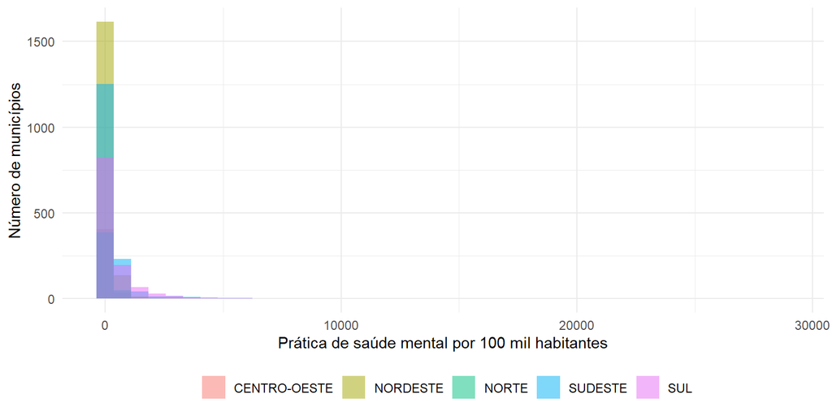

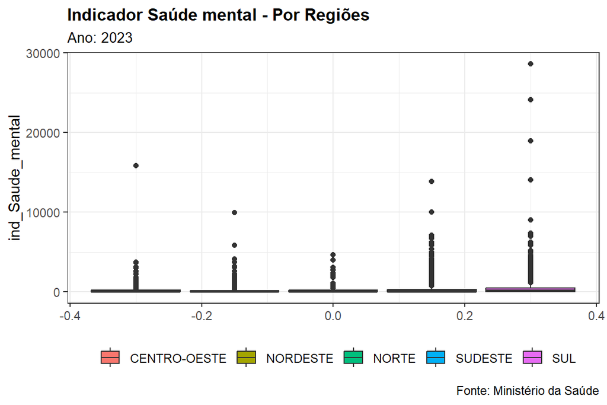

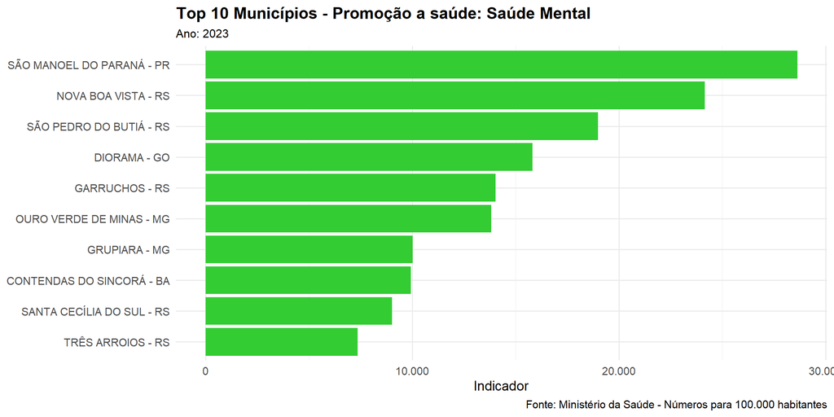

# 5.3 Indicadores de Alimentação saudável

## Dados por UF

| UF | Regiao | Indicador | Media | Mediana | Desvio_pad | Minimo | Maximo | Pvalor_shapiro | Numerador | Denominador | num_municip |
| --- | --- | --- | --- | --- | --- | --- | --- | --- | --- | --- | --- |
| DISTRITO FEDERAL | CENTRO-OESTE | 0.33 | 0.33 | 0.33 | NA | 0.33 | 0.33 | NA | 7 | 2091149 | 1 |
| GOIAS | CENTRO-OESTE | 182.36 | 426.37 | 132.04 | 1295.20 | 0.00 | 17443.80 | 0.00000 | 9661 | 5297680 | 239 |
| MATO GROSSO | CENTRO-OESTE | 175.58 | 254.90 | 131.96 | 381.14 | 0.00 | 3037.82 | 0.00000 | 5412 | 3082321 | 140 |
| MATO GROSSO DO SUL | CENTRO-OESTE | 133.06 | 215.97 | 124.60 | 275.70 | 0.00 | 1640.62 | 0.00000 | 3298 | 2478654 | 79 |
| ALAGOAS | NORDESTE | 524.46 | 707.46 | 339.72 | 1043.48 | 0.00 | 6554.66 | 0.00000 | 13388 | 2552709 | 102 |
| BAHIA | NORDESTE | 213.49 | 351.84 | 157.62 | 695.02 | 0.00 | 9140.37 | 0.00000 | 25958 | 12158963 | 415 |
| CEARA | NORDESTE | 191.87 | 391.90 | 178.02 | 602.39 | 0.00 | 4609.85 | 0.00000 | 16810 | 8761012 | 184 |
| MARANHAO | NORDESTE | 210.51 | 243.74 | 157.87 | 342.10 | 0.00 | 3795.89 | 0.00000 | 12677 | 6022076 | 216 |
| PARAIBA | NORDESTE | 201.67 | 272.45 | 149.74 | 422.89 | 0.00 | 2657.72 | 0.00000 | 7614 | 3775421 | 219 |
| PERNAMBUCO | NORDESTE | 298.00 | 428.66 | 261.19 | 578.38 | 0.00 | 4495.12 | 0.00000 | 22453 | 7534514 | 185 |
| PIAUI | NORDESTE | 295.99 | 440.43 | 220.47 | 802.13 | 0.00 | 6716.58 | 0.00000 | 9428 | 3185217 | 215 |
| RIO GRANDE DO NORTE | NORDESTE | 215.37 | 350.19 | 186.92 | 681.72 | 0.00 | 6484.32 | 0.00000 | 6204 | 2880619 | 167 |
| SERGIPE | NORDESTE | 116.35 | 218.16 | 110.11 | 465.68 | 0.00 | 3226.94 | 0.00000 | 2555 | 2196034 | 75 |
| ACRE | NORTE | 150.13 | 295.12 | 93.77 | 488.03 | 2.25 | 2217.23 | 0.00000 | 1036 | 690071 | 21 |
| AMAPA | NORTE | 212.29 | 227.99 | 173.72 | 230.81 | 17.79 | 913.19 | 0.00244 | 1010 | 475774 | 16 |
| AMAZONAS | NORTE | 240.47 | 785.36 | 368.54 | 1210.30 | 0.00 | 6835.09 | 0.00000 | 7629 | 3172538 | 62 |
| PARA | NORTE | 279.36 | 438.56 | 208.42 | 851.94 | 0.00 | 7548.23 | 0.00000 | 16030 | 5738072 | 141 |
| RONDONIA | NORTE | 104.22 | 161.09 | 88.47 | 238.38 | 0.00 | 1144.94 | 0.00000 | 1476 | 1416214 | 52 |
| RORAIMA | NORTE | 77.10 | 94.05 | 71.46 | 117.46 | 0.00 | 435.10 | 0.00232 | 421 | 546019 | 15 |
| TOCANTINS | NORTE | 346.30 | 434.24 | 170.45 | 917.08 | 0.00 | 6132.08 | 0.00000 | 5172 | 1493485 | 136 |
| ESPIRITO SANTO | SUDESTE | 101.41 | 132.21 | 94.58 | 165.31 | 0.00 | 871.93 | 0.00000 | 2285 | 2253138 | 33 |
| MINAS GERAIS | SUDESTE | 426.24 | 875.17 | 489.62 | 1428.92 | 0.00 | 18189.42 | 0.00000 | 81864 | 19206147 | 851 |
| RIO DE JANEIRO | SUDESTE | 95.05 | 204.12 | 116.77 | 234.93 | 0.00 | 1125.28 | 0.00000 | 11023 | 11596713 | 91 |
| SAO PAULO | SUDESTE | 85.69 | 200.60 | 46.83 | 547.73 | 0.00 | 8022.56 | 0.00000 | 25567 | 29837306 | 607 |
| PARANA | SUL | 117.55 | 206.05 | 62.38 | 428.14 | 0.00 | 5923.93 | 0.00000 | 11917 | 10137924 | 382 |
| RIO GRANDE DO SUL | SUL | 302.09 | 619.51 | 353.46 | 840.25 | 0.00 | 8874.08 | 0.00000 | 26959 | 8924305 | 491 |
| SANTA CATARINA | SUL | 137.46 | 289.61 | 96.65 | 584.25 | 0.00 | 6513.16 | 0.00000 | 9662 | 7029192 | 286 |

Note:  
*A coluna indicador foi calculada pela divisão do total de praticas adotadas (por UF, Regiao ou país) pela coluna de total de população cadastrada no IBGE.

## Dados por Região

| Regiao | Indicador | Media | Mediana | Desvio_pad | Min | Max | Pvalor_shapiro | Numerador | Denominador | num_municip |
| --- | --- | --- | --- | --- | --- | --- | --- | --- | --- | --- |
| CENTRO-OESTE | 141.92 | 336.93 | 130.51 | 968.39 | 0 | 17443.80 | 0 | 18378 | 12949804 | 459 |
| NORDESTE | 238.63 | 366.39 | 175.26 | 651.30 | 0 | 9140.37 | 0 | 117087 | 49066565 | 1778 |
| NORTE | 242.19 | 427.13 | 173.55 | 860.77 | 0 | 7548.23 | 0 | 32774 | 13532173 | 443 |
| SUDESTE | 191.97 | 562.24 | 231.20 | 1153.52 | 0 | 18189.42 | 0 | 120739 | 62893304 | 1582 |
| SUL | 186.03 | 401.83 | 174.65 | 692.04 | 0 | 8874.08 | 0 | 48538 | 26091421 | 1159 |

Note:  
*A coluna indicador foi calculada pela divisão do total de práticas adotadas (por UF, Regiao ou país) pela coluna de população cadastrada segundo o IBGE.

## Dados Nacionais

| Pais | Indicador | Media | Mediana | Desvio_pad | Min | Max | Pvalor_shapiro | Numerador | Denominador | num_municip |
| --- | --- | --- | --- | --- | --- | --- | --- | --- | --- | --- |
| Brasil | 205.14 | 433.59 | 182.88 | 881.2 | 0 | 18189.42 | NA | 337516 | 164533267 | 5421 |

Note:  
*A coluna indicador foi calculada pela divisão do total de práticas adotadas (por UF, Regiao ou país) pela população cadastrada segundo o IBGE.

## Gráficos

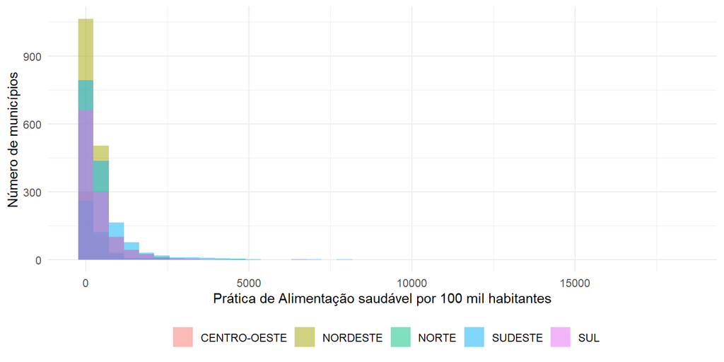

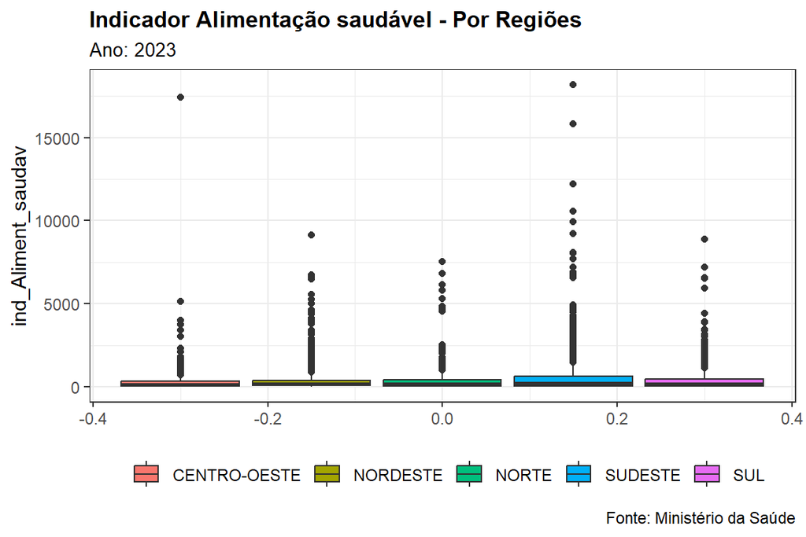

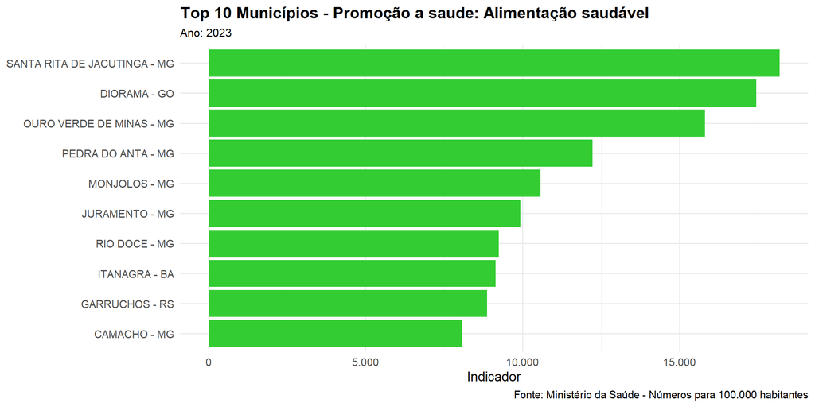

# 5.4 Indicadores de práticas de saúde sexual e reprodutiva

## Dados por UF

| UF | Regiao | Indicador | Media | Mediana | Desvio_pad | Min | Max | Pvalor_shapiro | Numerador | Denominador | num_municip |
| --- | --- | --- | --- | --- | --- | --- | --- | --- | --- | --- | --- |
| DISTRITO FEDERAL | CENTRO-OESTE | 0.10 | 0.10 | 0.10 | NA | 0.1 | 0.10 | NA | 2 | 2091149 | 1 |
| GOIAS | CENTRO-OESTE | 38.66 | 99.54 | 33.69 | 472.30 | 0.0 | 7171.85 | 0.00000 | 2048 | 5297680 | 239 |
| MATO GROSSO | CENTRO-OESTE | 94.31 | 93.61 | 52.11 | 123.28 | 0.0 | 826.77 | 0.00000 | 2907 | 3082321 | 140 |
| MATO GROSSO DO SUL | CENTRO-OESTE | 82.99 | 72.91 | 50.70 | 77.80 | 0.0 | 373.60 | 0.00000 | 2057 | 2478654 | 79 |
| ALAGOAS | NORDESTE | 176.09 | 215.89 | 103.60 | 342.32 | 0.0 | 2721.25 | 0.00000 | 4495 | 2552709 | 102 |
| BAHIA | NORDESTE | 103.46 | 127.19 | 70.48 | 237.14 | 0.0 | 3082.19 | 0.00000 | 12580 | 12158963 | 415 |
| CEARA | NORDESTE | 66.91 | 137.75 | 75.40 | 203.05 | 0.0 | 1472.93 | 0.00000 | 5862 | 8761012 | 184 |
| MARANHAO | NORDESTE | 107.21 | 107.61 | 89.86 | 97.42 | 0.0 | 638.62 | 0.00000 | 6456 | 6022076 | 216 |
| PARAIBA | NORDESTE | 66.40 | 95.06 | 64.51 | 120.80 | 0.0 | 943.00 | 0.00000 | 2507 | 3775421 | 219 |
| PERNAMBUCO | NORDESTE | 103.01 | 131.75 | 88.35 | 160.11 | 0.0 | 1296.57 | 0.00000 | 7761 | 7534514 | 185 |
| PIAUI | NORDESTE | 94.75 | 111.21 | 53.44 | 151.05 | 0.0 | 1035.44 | 0.00000 | 3018 | 3185217 | 215 |
| RIO GRANDE DO NORTE | NORDESTE | 84.01 | 111.19 | 73.38 | 117.32 | 0.0 | 551.16 | 0.00000 | 2420 | 2880619 | 167 |
| SERGIPE | NORDESTE | 39.30 | 63.66 | 35.61 | 67.87 | 0.0 | 320.46 | 0.00000 | 863 | 2196034 | 75 |
| ACRE | NORTE | 123.47 | 142.98 | 62.03 | 159.91 | 0.0 | 561.32 | 0.00054 | 852 | 690071 | 21 |
| AMAPA | NORTE | 66.00 | 69.86 | 41.59 | 65.38 | 0.0 | 196.68 | 0.01107 | 314 | 475774 | 16 |
| AMAZONAS | NORTE | 148.52 | 454.75 | 226.98 | 901.83 | 0.0 | 6400.00 | 0.00000 | 4712 | 3172538 | 62 |
| PARA | NORTE | 160.54 | 178.16 | 98.74 | 255.93 | 0.0 | 2172.69 | 0.00000 | 9212 | 5738072 | 141 |
| RONDONIA | NORTE | 122.44 | 96.87 | 68.35 | 109.58 | 0.0 | 624.51 | 0.00000 | 1734 | 1416214 | 52 |
| RORAIMA | NORTE | 92.85 | 104.80 | 83.74 | 116.58 | 0.0 | 362.18 | 0.01528 | 507 | 546019 | 15 |
| TOCANTINS | NORTE | 125.61 | 162.30 | 80.89 | 279.00 | 0.0 | 2242.05 | 0.00000 | 1876 | 1493485 | 136 |
| ESPIRITO SANTO | SUDESTE | 38.57 | 60.16 | 25.41 | 100.31 | 0.0 | 493.78 | 0.00000 | 869 | 2253138 | 33 |
| MINAS GERAIS | SUDESTE | 153.41 | 240.29 | 165.68 | 279.60 | 0.0 | 3476.00 | 0.00000 | 29465 | 19206147 | 851 |
| RIO DE JANEIRO | SUDESTE | 48.76 | 102.24 | 61.30 | 115.63 | 0.0 | 573.56 | 0.00000 | 5655 | 11596713 | 91 |
| SAO PAULO | SUDESTE | 44.77 | 65.37 | 24.72 | 111.20 | 0.0 | 894.92 | 0.00000 | 13359 | 29837306 | 607 |
| PARANA | SUL | 26.54 | 42.79 | 17.01 | 74.18 | 0.0 | 609.55 | 0.00000 | 2691 | 10137924 | 382 |
| RIO GRANDE DO SUL | SUL | 72.88 | 128.94 | 60.94 | 183.74 | 0.0 | 1877.93 | 0.00000 | 6504 | 8924305 | 491 |
| SANTA CATARINA | SUL | 29.15 | 75.65 | 28.39 | 131.79 | 0.0 | 715.27 | 0.00000 | 2049 | 7029192 | 286 |

Note:  
*A coluna indicador foi calculada pela divisão do total de praticas adotadas (por UF, Regiao ou país) pela coluna de total de população cadastrada no IBGE.

## Dados por Regiao

| Regiao | Indicador | Media | Mediana | Desvio_pad | Min | Max | Pvalor_shapiro | Numerador | Denominador | num_municip |
| --- | --- | --- | --- | --- | --- | --- | --- | --- | --- | --- |
| CENTRO-OESTE | 54.16 | 92.93 | 40.81 | 348.82 | 0 | 7171.85 | 0 | 7014 | 12949804 | 459 |
| NORDESTE | 93.67 | 121.40 | 73.80 | 186.16 | 0 | 3082.19 | 0 | 45962 | 49066565 | 1778 |
| NORTE | 141.94 | 194.40 | 91.14 | 414.57 | 0 | 6400.00 | 0 | 19207 | 13532173 | 443 |
| SUDESTE | 78.46 | 161.47 | 95.10 | 234.61 | 0 | 3476.00 | 0 | 49348 | 62893304 | 1582 |
| SUL | 43.09 | 87.40 | 36.15 | 147.63 | 0 | 1877.93 | 0 | 11244 | 26091421 | 1159 |

Note:  
*A coluna indicador foi calculada pela divisão do total de práticas adotadas (por UF, Regiao ou país) pela coluna de população cadastrada segundo o IBGE.

## Dados Nacionais

| Pais | Indicador | Media | Mediana | Desvio_pad | Min | Max | pvalor_shapiro | Numerador | Denominador | num_municip |
| --- | --- | --- | --- | --- | --- | --- | --- | --- | --- | --- |
| Brasil | 80.7 | 129.38 | 65.93 | 239.85 | 0 | 7171.85 | NA | 132775 | 164533267 | 5421 |

Note:  
*A coluna indicador foi calculada pela divisão do total de práticas adotadas (por UF, Regiao ou país) pela população cadastrada segundo o IBGE.

## Gráficos

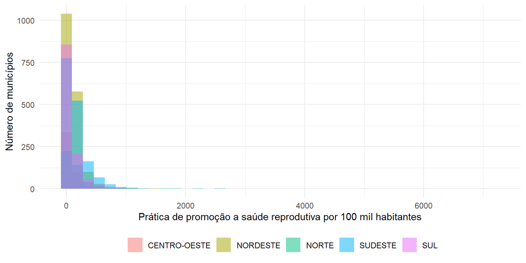

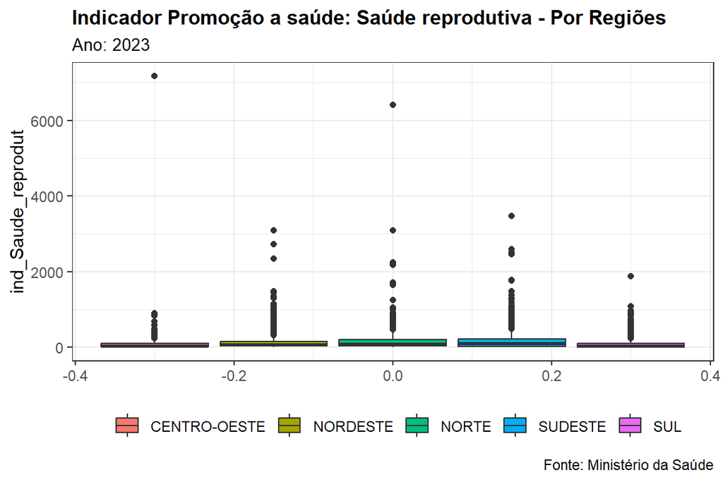

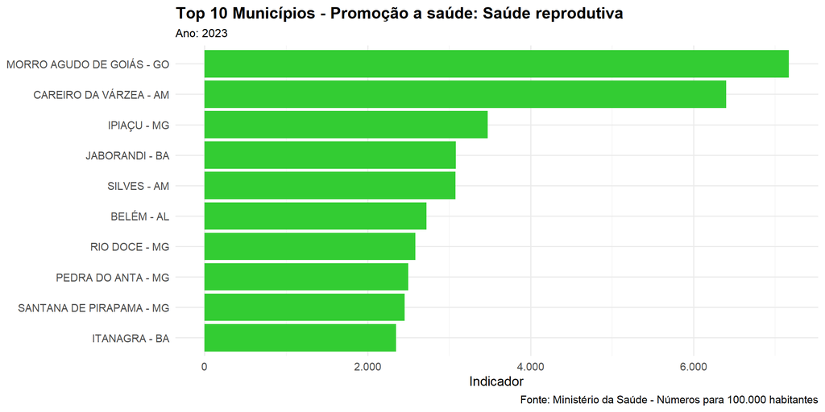

# 5.5 Indicadores de práticas autocuidado

## Dados por UF

| UF | Regiao | Indicador | Media | Mediana | Desvio_pad | Min | Max | Pvalor_shapiro | Numerador | Denominador | num_municip |
| --- | --- | --- | --- | --- | --- | --- | --- | --- | --- | --- | --- |
| DISTRITO FEDERAL | CENTRO-OESTE | 0.43 | 0.43 | 0.43 | NA | 0.43 | 0.43 | NA | 9 | 2091149 | 1 |
| GOIAS | CENTRO-OESTE | 179.08 | 447.06 | 67.62 | 1356.79 | 0.00 | 13696.92 | 0.00000 | 9487 | 5297680 | 239 |
| MATO GROSSO | CENTRO-OESTE | 137.56 | 195.88 | 36.08 | 860.97 | 0.00 | 9770.49 | 0.00000 | 4240 | 3082321 | 140 |
| MATO GROSSO DO SUL | CENTRO-OESTE | 83.31 | 147.75 | 57.94 | 245.18 | 0.00 | 1500.33 | 0.00000 | 2065 | 2478654 | 79 |
| ALAGOAS | NORDESTE | 291.89 | 375.05 | 55.27 | 909.40 | 0.00 | 6507.34 | 0.00000 | 7451 | 2552709 | 102 |
| BAHIA | NORDESTE | 140.28 | 203.26 | 38.13 | 590.00 | 0.00 | 5022.46 | 0.00000 | 17056 | 12158963 | 415 |
| CEARA | NORDESTE | 136.45 | 253.47 | 32.16 | 608.76 | 0.00 | 3654.03 | 0.00000 | 11954 | 8761012 | 184 |
| MARANHAO | NORDESTE | 141.93 | 151.89 | 28.85 | 478.71 | 0.00 | 4939.16 | 0.00000 | 8547 | 6022076 | 216 |
| PARAIBA | NORDESTE | 229.27 | 305.75 | 48.16 | 913.48 | 0.00 | 7504.90 | 0.00000 | 8656 | 3775421 | 219 |
| PERNAMBUCO | NORDESTE | 186.24 | 265.89 | 93.99 | 572.05 | 0.00 | 5081.94 | 0.00000 | 14032 | 7534514 | 185 |
| PIAUI | NORDESTE | 245.07 | 347.97 | 45.89 | 1187.91 | 0.00 | 12833.75 | 0.00000 | 7806 | 3185217 | 215 |
| RIO GRANDE DO NORTE | NORDESTE | 201.14 | 276.06 | 56.32 | 917.89 | 0.00 | 7405.47 | 0.00000 | 5794 | 2880619 | 167 |
| SERGIPE | NORDESTE | 92.99 | 300.50 | 20.54 | 1316.95 | 0.00 | 8818.39 | 0.00000 | 2042 | 2196034 | 75 |
| ACRE | NORTE | 148.83 | 179.23 | 27.14 | 315.26 | 0.00 | 1234.91 | 0.00001 | 1027 | 690071 | 21 |
| AMAPA | NORTE | 139.14 | 67.41 | 30.50 | 82.03 | 0.00 | 257.54 | 0.00122 | 662 | 475774 | 16 |
| AMAZONAS | NORTE | 134.94 | 343.95 | 71.09 | 723.96 | 0.00 | 4327.75 | 0.00000 | 4281 | 3172538 | 62 |
| PARA | NORTE | 194.28 | 278.83 | 46.57 | 631.00 | 0.00 | 3689.54 | 0.00000 | 11148 | 5738072 | 141 |
| RONDONIA | NORTE | 76.82 | 65.76 | 30.18 | 90.46 | 0.00 | 390.32 | 0.00000 | 1088 | 1416214 | 52 |
| RORAIMA | NORTE | 120.33 | 170.07 | 25.01 | 379.87 | 0.00 | 1472.56 | 0.00000 | 657 | 546019 | 15 |
| TOCANTINS | NORTE | 267.23 | 404.03 | 74.19 | 1061.25 | 0.00 | 7540.44 | 0.00000 | 3991 | 1493485 | 136 |
| ESPIRITO SANTO | SUDESTE | 74.25 | 55.54 | 26.38 | 74.04 | 0.00 | 347.48 | 0.00000 | 1673 | 2253138 | 33 |
| MINAS GERAIS | SUDESTE | 348.78 | 743.26 | 202.08 | 1607.08 | 0.00 | 21790.54 | 0.00000 | 66988 | 19206147 | 851 |
| RIO DE JANEIRO | SUDESTE | 43.31 | 88.42 | 27.22 | 146.22 | 0.00 | 873.97 | 0.00000 | 5022 | 11596713 | 91 |
| SAO PAULO | SUDESTE | 100.31 | 312.41 | 32.64 | 1113.98 | 0.00 | 12689.70 | 0.00000 | 29931 | 29837306 | 607 |
| PARANA | SUL | 94.84 | 165.64 | 20.59 | 540.16 | 0.00 | 7221.32 | 0.00000 | 9615 | 10137924 | 382 |
| RIO GRANDE DO SUL | SUL | 216.01 | 469.28 | 152.21 | 1418.36 | 0.00 | 22307.96 | 0.00000 | 19277 | 8924305 | 491 |
| SANTA CATARINA | SUL | 139.06 | 297.42 | 37.39 | 1216.05 | 0.00 | 17855.56 | 0.00000 | 9775 | 7029192 | 286 |

Note:  
*A coluna indicador foi calculada pela divisão do total de praticas adotadas (por UF, Regiao ou país) pela coluna de total de população cadastrada no IBGE.

## Dados por Regiao

| Regiao | Indicador | Media | Mediana | Desvio_padrao | Minimo | Maximo | Pvalor_shapiro | Numerador | Denominador | num_municip |
| --- | --- | --- | --- | --- | --- | --- | --- | --- | --- | --- |
| CENTRO-OESTE | 122.02 | 317.96 | 51.57 | 1100.13 | 0 | 13696.92 | 0 | 15801 | 12949804 | 459 |
| NORDESTE | 169.85 | 259.65 | 41.92 | 809.53 | 0 | 12833.75 | 0 | 83338 | 49066565 | 1778 |
| NORTE | 168.89 | 285.33 | 49.94 | 752.26 | 0 | 7540.44 | 0 | 22854 | 13532173 | 443 |
| SUDESTE | 164.75 | 525.93 | 103.17 | 1387.12 | 0 | 21790.54 | 0 | 103614 | 62893304 | 1582 |
| SUL | 148.20 | 326.79 | 67.99 | 1152.64 | 0 | 22307.96 | 0 | 38667 | 26091421 | 1159 |

Note:  
*A coluna indicador foi calculada pela divisão do total de práticas adotadas (por UF, Regiao ou país) pela coluna de população cadastrada segundo o IBGE.

## Dados Nacionais

[output not shown]

Note:  
*A coluna indicador foi calculada pela divisão do total de práticas adotadas (por UF, Regiao ou país) pela população cadastrada segundo o IBGE.

## Gráficos

[figure not shown]

[figure not shown]

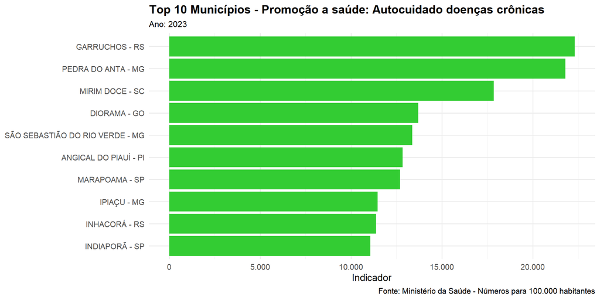

# 5.6 Indicadores de Práticas de Antropometria

## Dados por UF

| UF | Regiao | Indicador | Media | Mediana | Desvio_pad | Min | Max | Pvalor_shapiro | Numerador | Denominador | num_municip |
| --- | --- | --- | --- | --- | --- | --- | --- | --- | --- | --- | --- |
| DISTRITO FEDERAL | CENTRO-OESTE | 0.10 | 0.10 | 0.10 | NA | 0.1 | 0.10 | NA | 2 | 2091149 | 1 |
| GOIAS | CENTRO-OESTE | 150.00 | 252.70 | 61.12 | 488.77 | 0.0 | 5100.05 | 0.00000 | 7928 | 5285178 | 231 |
| MATO GROSSO | CENTRO-OESTE | 130.90 | 169.73 | 97.78 | 217.98 | 0.0 | 1400.02 | 0.00000 | 4021 | 3071752 | 138 |
| MATO GROSSO DO SUL | CENTRO-OESTE | 167.92 | 185.46 | 86.98 | 290.38 | 0.0 | 2031.25 | 0.00000 | 4153 | 2473265 | 78 |
| ALAGOAS | NORDESTE | 195.44 | 256.31 | 125.87 | 328.79 | 0.0 | 1869.26 | 0.00000 | 4989 | 2552709 | 102 |
| BAHIA | NORDESTE | 118.81 | 175.34 | 54.95 | 396.32 | 0.0 | 5283.76 | 0.00000 | 14118 | 11882677 | 397 |
| CEARA | NORDESTE | 108.95 | 218.60 | 98.22 | 339.77 | 0.0 | 2770.23 | 0.00000 | 9523 | 8740685 | 182 |
| MARANHAO | NORDESTE | 166.55 | 197.24 | 98.79 | 268.15 | 0.0 | 1844.58 | 0.00000 | 9955 | 5977174 | 209 |
| PARAIBA | NORDESTE | 194.87 | 311.60 | 85.04 | 651.87 | 0.0 | 5073.83 | 0.00000 | 7256 | 3723470 | 212 |
| PERNAMBUCO | NORDESTE | 150.39 | 217.33 | 60.37 | 408.61 | 0.0 | 3019.62 | 0.00000 | 11331 | 7534514 | 185 |
| PIAUI | NORDESTE | 166.99 | 243.10 | 91.06 | 460.75 | 0.0 | 4787.62 | 0.00000 | 5237 | 3136094 | 207 |
| RIO GRANDE DO NORTE | NORDESTE | 139.47 | 225.25 | 104.89 | 453.44 | 0.0 | 4177.08 | 0.00000 | 4011 | 2875806 | 166 |
| SERGIPE | NORDESTE | 96.08 | 174.68 | 55.76 | 326.09 | 0.0 | 2135.96 | 0.00000 | 2101 | 2186702 | 73 |
| ACRE | NORTE | 208.67 | 353.70 | 71.51 | 679.09 | 0.0 | 3017.24 | 0.00000 | 1440 | 690071 | 21 |
| AMAPA | NORTE | 225.74 | 193.31 | 125.40 | 253.83 | 0.0 | 813.82 | 0.00012 | 1074 | 475774 | 16 |
| AMAZONAS | NORTE | 185.46 | 498.25 | 293.69 | 707.18 | 0.0 | 4492.31 | 0.00000 | 5842 | 3150059 | 60 |
| PARA | NORTE | 177.73 | 275.53 | 111.08 | 467.30 | 0.0 | 3855.01 | 0.00000 | 10150 | 5711063 | 138 |
| RONDONIA | NORTE | 135.71 | 166.34 | 77.17 | 220.23 | 0.0 | 1112.03 | 0.00000 | 1922 | 1416214 | 52 |
| RORAIMA | NORTE | 28.20 | 58.15 | 15.09 | 92.08 | 0.0 | 298.49 | 0.00073 | 143 | 507119 | 12 |
| TOCANTINS | NORTE | 165.08 | 309.33 | 70.42 | 738.98 | 0.0 | 6856.19 | 0.00000 | 2387 | 1445992 | 126 |
| ESPIRITO SANTO | SUDESTE | 61.50 | 58.82 | 20.09 | 92.93 | 0.0 | 433.03 | 0.00000 | 1368 | 2224465 | 31 |
| MINAS GERAIS | SUDESTE | 152.89 | 318.07 | 92.87 | 933.55 | 0.0 | 18168.51 | 0.00000 | 29317 | 19175304 | 844 |
| RIO DE JANEIRO | SUDESTE | 55.12 | 116.25 | 42.94 | 245.15 | 0.0 | 1852.49 | 0.00000 | 6340 | 11501317 | 87 |
| SAO PAULO | SUDESTE | 56.01 | 132.42 | 21.95 | 304.92 | 0.0 | 2937.00 | 0.00000 | 16386 | 29253025 | 553 |
| PARANA | SUL | 115.02 | 220.64 | 47.09 | 377.57 | 0.0 | 2282.55 | 0.00000 | 11454 | 9957845 | 364 |
| RIO GRANDE DO SUL | SUL | 157.60 | 304.79 | 114.12 | 598.00 | 0.0 | 7661.59 | 0.00000 | 13951 | 8852111 | 478 |
| SANTA CATARINA | SUL | 80.70 | 220.87 | 33.83 | 599.41 | 0.0 | 8289.47 | 0.00000 | 5546 | 6872446 | 269 |

Note:  
*A coluna indicador foi calculada pela divisão do total de praticas adotadas (por UF, Regiao ou país) pela coluna de total de população cadastrada no IBGE.

## Dados por Regiao

| Regiao | indicador | Media | Mediana | Desvio_pad | Minimo | Maximo | Pvalor_shapiro | Numerador | Denominador | num_municip |
| --- | --- | --- | --- | --- | --- | --- | --- | --- | --- | --- |
| CENTRO-OESTE | 124.63 | 214.87 | 81.09 | 391.96 | 0 | 5100.05 | 0 | 16104 | 12921344 | 448 |
| NORDESTE | 140.96 | 221.29 | 80.23 | 428.31 | 0 | 5283.76 | 0 | 68521 | 48609831 | 1733 |
| NORTE | 171.38 | 298.27 | 103.95 | 584.32 | 0 | 6856.19 | 0 | 22958 | 13396292 | 425 |
| SUDESTE | 85.93 | 233.41 | 53.57 | 729.30 | 0 | 18168.51 | 0 | 53411 | 62154111 | 1515 |
| SUL | 120.51 | 256.90 | 70.49 | 537.38 | 0 | 8289.47 | 0 | 30951 | 25682402 | 1111 |

Note:  
*A coluna indicador foi calculada pela divisão do total de práticas adotadas (por UF, Regiao ou país) pela coluna de população cadastrada segundo o IBGE.

## Dados Nacionais

| Pais | Indicador | Media | Mediana | Desvio_pad | Min | Max | Pvalor_shapiro | Numerador | Denominador | num_municip |
| --- | --- | --- | --- | --- | --- | --- | --- | --- | --- | --- |
| Brasil | 117.93 | 238.06 | 70.55 | 563.27 | 0 | 18168.51 | NA | 191945 | 162763980 | 5232 |

Note:  
*A coluna indicador foi calculada pela divisão do total de práticas adotadas (por UF, Regiao ou país) pela população cadastrada segundo o IBGE.

## Gráficos

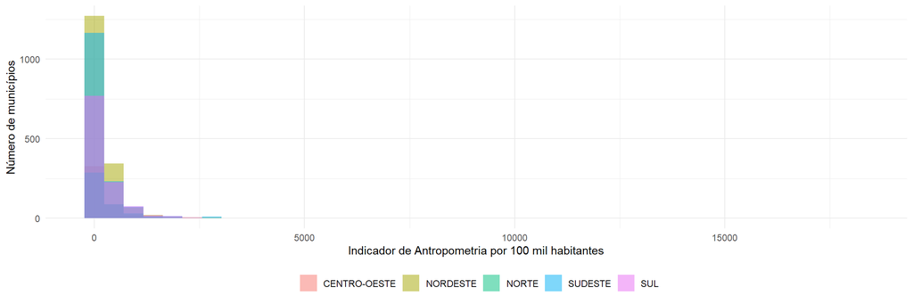

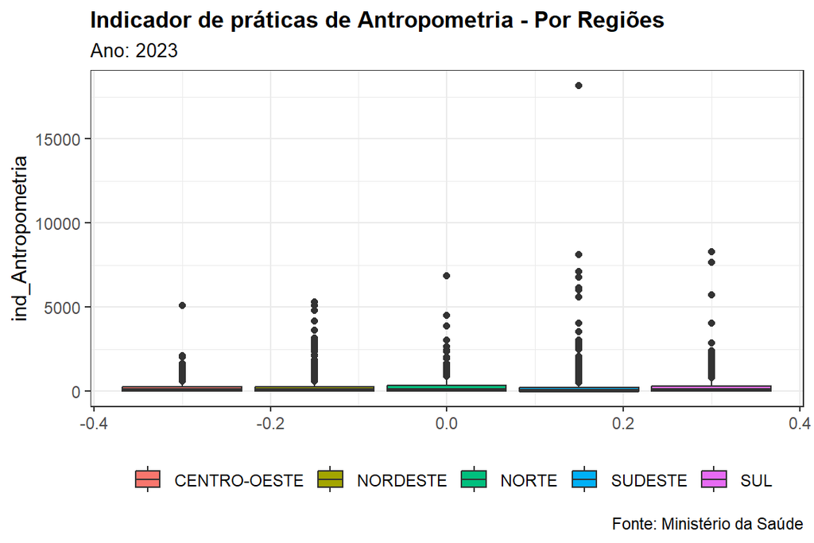

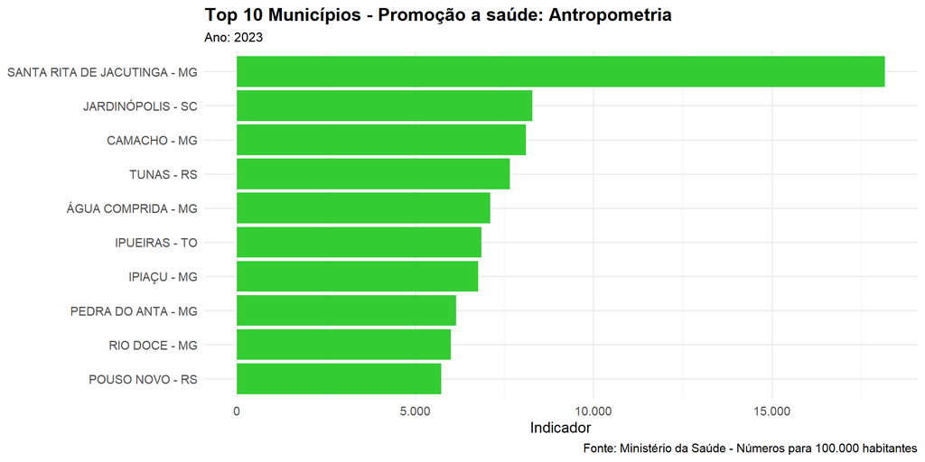

# 5.7 Indicadores de Práticas de saúde pratica de atividades

## Dados por UF

| UF | Regiao | Indicador | Media | Mediana | Desvio_pad | Min | Max | Pvalor_shapiro | Numerador | Denominador | num_municip |
| --- | --- | --- | --- | --- | --- | --- | --- | --- | --- | --- | --- |
| DISTRITO FEDERAL | CENTRO-OESTE | 0.19 | 4.00 | 4.0 | NA | 4 | 4 | NA | 4 | 2091149 | 1 |
| GOIAS | CENTRO-OESTE | 613.56 | 140.38 | 48.0 | 200.32 | 0 | 959 | 0.00000 | 32428 | 5285178 | 231 |
| MATO GROSSO | CENTRO-OESTE | 244.23 | 54.36 | 3.0 | 128.41 | 0 | 687 | 0.00000 | 7502 | 3071752 | 138 |
| MATO GROSSO DO SUL | CENTRO-OESTE | 66.83 | 21.19 | 1.0 | 66.00 | 0 | 426 | 0.00000 | 1653 | 2473265 | 78 |
| ALAGOAS | NORDESTE | 710.50 | 177.81 | 43.0 | 243.13 | 0 | 910 | 0.00000 | 18137 | 2552709 | 102 |
| BAHIA | NORDESTE | 316.64 | 94.77 | 7.0 | 176.48 | 0 | 963 | 0.00000 | 37625 | 11882677 | 397 |
| CEARA | NORDESTE | 345.48 | 165.92 | 41.0 | 231.53 | 0 | 951 | 0.00000 | 30197 | 8740685 | 182 |
| MARANHAO | NORDESTE | 277.54 | 79.37 | 15.0 | 167.40 | 0 | 968 | 0.00000 | 16589 | 5977174 | 209 |
| PARAIBA | NORDESTE | 644.08 | 113.12 | 4.0 | 210.79 | 0 | 941 | 0.00000 | 23982 | 3723470 | 212 |
| PERNAMBUCO | NORDESTE | 308.34 | 125.58 | 7.0 | 231.99 | 0 | 990 | 0.00000 | 23232 | 7534514 | 185 |
| PIAUI | NORDESTE | 775.84 | 117.54 | 11.0 | 209.51 | 0 | 992 | 0.00000 | 24331 | 3136094 | 207 |
| RIO GRANDE DO NORTE | NORDESTE | 471.49 | 81.68 | 10.0 | 149.75 | 0 | 985 | 0.00000 | 13559 | 2875806 | 166 |
| SERGIPE | NORDESTE | 219.01 | 65.60 | 2.0 | 125.41 | 0 | 613 | 0.00000 | 4789 | 2186702 | 73 |
| ACRE | NORTE | 143.75 | 47.24 | 20.0 | 65.80 | 0 | 219 | 0.00007 | 992 | 690071 | 21 |
| AMAPA | NORTE | 59.27 | 17.62 | 13.5 | 17.17 | 0 | 55 | 0.07031 | 282 | 475774 | 16 |
| AMAZONAS | NORTE | 378.31 | 198.62 | 62.0 | 243.93 | 0 | 921 | 0.00000 | 11917 | 3150059 | 60 |
| PARA | NORTE | 371.14 | 153.59 | 39.5 | 244.86 | 0 | 996 | 0.00000 | 21196 | 5711063 | 138 |
| RONDONIA | NORTE | 79.44 | 21.63 | 0.0 | 100.01 | 0 | 718 | 0.00000 | 1125 | 1416214 | 52 |
| RORAIMA | NORTE | 177.08 | 74.83 | 19.0 | 154.84 | 0 | 549 | 0.00003 | 898 | 507119 | 12 |
| TOCANTINS | NORTE | 580.78 | 66.65 | 10.0 | 129.24 | 0 | 796 | 0.00000 | 8398 | 1445992 | 126 |
| ESPIRITO SANTO | SUDESTE | 56.10 | 40.26 | 3.0 | 111.31 | 0 | 447 | 0.00000 | 1248 | 2224465 | 31 |
| MINAS GERAIS | SUDESTE | 875.75 | 198.97 | 133.0 | 216.51 | 0 | 992 | 0.00000 | 167928 | 19175304 | 844 |
| RIO DE JANEIRO | SUDESTE | 71.09 | 93.98 | 10.0 | 180.40 | 0 | 904 | 0.00000 | 8176 | 11501317 | 87 |
| SAO PAULO | SUDESTE | 147.52 | 78.03 | 3.0 | 159.34 | 0 | 981 | 0.00000 | 43153 | 29253025 | 553 |
| PARANA | SUL | 200.74 | 54.91 | 1.0 | 142.47 | 0 | 916 | 0.00000 | 19989 | 9957845 | 364 |
| RIO GRANDE DO SUL | SUL | 446.63 | 82.71 | 16.0 | 143.66 | 0 | 873 | 0.00000 | 39536 | 8852111 | 478 |
| SANTA CATARINA | SUL | 333.99 | 85.33 | 3.0 | 168.47 | 0 | 999 | 0.00000 | 22953 | 6872446 | 269 |

Note:  
*A coluna indicador foi calculada pela divisão do total de praticas adotadas (por UF, Regiao ou país) pela coluna de total de população cadastrada no IBGE.

## Dados por Regiao

| Regiao | indicador | Media | Mediana | Desvio_pad | Minimo | Maximo | Pvalor_shapiro | Numerador | Denominador | num_municip |
| --- | --- | --- | --- | --- | --- | --- | --- | --- | --- | --- |
| CENTRO-OESTE | 321.85 | 1353.59 | 71.16 | 3719.28 | 0 | 50341.21 | 0 | 606408.9 | 12921344 | 448 |
| NORDESTE | 395.89 | 845.41 | 67.93 | 1833.24 | 0 | 16582.68 | 0 | 1465087.0 | 48609831 | 1733 |
| NORTE | 334.48 | 837.10 | 117.97 | 1785.87 | 0 | 14243.21 | 0 | 355769.6 | 13396292 | 425 |
| SUDESTE | 354.77 | 1655.90 | 297.96 | 2937.00 | 0 | 27829.46 | 0 | 2508695.6 | 62154111 | 1515 |
| SUL | 321.15 | 1088.69 | 60.64 | 3366.59 | 0 | 36733.56 | 0 | 1209535.3 | 25682402 | 1111 |

Note:  
*A coluna indicador foi calculada pela divisão do total de práticas adotadas (por UF, Regiao ou país) pela coluna de população cadastrada segundo o IBGE.

## Dados Nacionais

| Pais | Indicador | Media | Mediana | Desvio_pad | Min | Max | Pvalor_shapiro | Numerador | Denominador | num_municip |
| --- | --- | --- | --- | --- | --- | --- | --- | --- | --- | --- |
| Brasil | 3775.71 | 1174.6 | 99.83 | 2751.64 | 0 | 50341.21 | NA | 6145496 | 162763980 | 5232 |

Note:  
*A coluna indicador foi calculada pela divisão do total de práticas adotadas (por UF, Regiao ou país) pela população cadastrada segundo o IBGE.